# Project- Fama French Funds

FIRE 540: Financial Analytics

Author

Affiliation

Larry Tentor

Virginia Commonwealth University

# Student Name

ROHITH RAVINDRA REDDY

## Academic Integrity Statement

*I, ROHITH RAVINDRA REDDY, hereby state that I have not communicated with or gained information in any way from my classmates or anyone other than the Professor or TA during this project, and that all work is my own.*

## Project Guidlines

1. **No Public Questions.** You are not allowed to post any questions on a public or private internet community (like StackOverflow). Any questions about the project must be asked in e-mails to faculty.
2. **Citation Necessary, Avoid Plagiarism.** I am well aware that a huge volume of code is available on the web to solve any number of problems. For this project you are allowed to make use of any online resources (e.g. R for Data Science book, StackOverflow) but you must explicitly cite where you obtained any code you directly use (or use as inspiration). You are also not allowed to ask a question on a forum, you may only use answers to questions that have already been answered. Any recycled code that is discovered and is not explicitly cited will be treated as plagiarism. All communication with classmates is explicitly forbidden.
3. **TidyVerse R Preferred.** Please use R and the modern tidyverse functions to solve the below challenges.
4. **Analysis Responses Necessary.** Please replace the **STUDENT RESPONSE REQUIRED** with complete sentences answers. All submitted work shall represent the student’s own thoughts and typing. Students may be asked to explain their answer. Each question may have a brief narrative or description of your approach. You can use comments in your code, but do not extensively count on these. Even if the answer seems obvious from the R output, make sure to state it in your analysis as well.
5. **Quarto Document, with HTML Submission.** Your solutions must be written up in the Quarto Markdown (qmd) file. This file must include your code and any text answers for each task. Your “submission” will be the rendered HTML output that you submit to Canvas. I should be able to suppress **all** the code in your document and still be able to read and make sense of your answers. See the first setup code chunk in your qmd file to experiment with suppressing and revealing your code.
6. **Instructor or TA to Answer Questions.** You **may not** consult with anyone else about this project other than the Professor or TA for this course. You cannot ask direct questions on the internet, or consult with each other, not even for hypothetical questions.
7. **Dates on Learning Management System.** The project due date is established via Canvas.

## Fama-French Three-Factor Fund Analysis

This case has been adapted from [WRDS Classroom](https://wrds-www.wharton.upenn.edu/classroom/stock-and-factor-returns/)

### Case Overview

In this exercise you are tasked performing a Fama-French three-factor analysis for five exchange-traded funds (ETFs). After the data is loaded, the students complete the analysis performing multiple linear regressions on the various funds’ returns using the Fama-French market, size, and value factors (which are provided in the data set). Students are asked to compare the results for the ETFs and analyze how well the excess returns are explained by the Fama-French three-factor model.

Although only the funds’ returns, the risk-free rate, and the Fama-French factors are required for this exercise, additional data is provided for those who wish to simplify the exercise to estimate a a single factor (CAPM) model, or extend it to a multi-factor model including momentum.

WRDS Classroom has reference materials demonstrating step-by-step instructions for performing a regression in Excel.

### Learning Objective

Upon completing this assignment, students will be able to:

```
•   Describe the Fama-French three-factor model
•   Build a regression model in R
•   Analyze how well an asset’s returns are explained by the Fama-French three-factor model
```

### Student Background

Typical students will have learned about the Capital Asset Pricing Model (CAPM) as a prerequisite to the Fama-French three-factor model. It is assumed that students have some basic knowledge of investments, including volatility, alpha, and beta. It would also be helpful for students to have a basic knowledge of statistics, including concepts such as regression analysis and covariance.

## Fund and Market Import

This project’s data contains monthly fund returns in addition to the market estimated from the Fama-French data sets.

**Access dataset `Fund Returns`**

```r
fileName   <- paste0(here(), '/course-material/_data/wrds-fund-returns.csv')
columnsFundReturn <- cols( MonthEnd            = readr::col_date('%Y-%m-%d')
                         , FundId              = readr::col_integer()
                         , ReturnMonthly       = readr::col_double()
                         )
returnsStack      <- read_csv( file            = fileName
                             , col_types       = columnsFundReturn
                             , na            = c('', 'NA', '--') )

fileName   <- paste0(here(), '/course-material/_data/wrds-fund-info.csv')
columnsFundReturn <- cols( FundId              = readr::col_integer()
                         , NameWRDS            = readr::col_character()
                         , Ticker              = readr::col_character()
                         , NameFund            = readr::col_character()
                         , Issuer              = readr::col_character()
                         , AUM                 = readr::col_character()
                         , ExpenseRatio        = readr::col_double()
                         , TotalReturn_3_month = readr::col_double()
                         , Segment             = readr::col_character()
                         )
fundInfo          <- read_csv( file          = fileName
                             , col_types     = columnsFundReturn
                             , na            = c('', 'NA', '--') )
```

## CRISP: Understand Data

There are two tibble that have been loaded for you.

`returnsStack` is a long form of monthly returns for various funds for the dates these were available from 2010-2024. All returns are measured at the end of the month from the prior month end. ReturnMonthly` column is in decimal notation, 0.01 = 1%.

**Review dataset `returnsStack`**

```r
returnsStack |>
  head(6) |>
  gt( )
```

Table 1: Sample Data from `returnsStack`

| MonthEnd | FundId | ReturnMonthly |
| --- | --- | --- |
| 2010-01-31 | 1 | -0.0336 |
| 2010-02-28 | 1 | 0.0340 |
| 2010-03-31 | 1 | 0.0631 |
| 2010-04-30 | 1 | 0.0200 |
| 2010-05-31 | 1 | -0.0789 |
| 2010-06-30 | 1 | -0.0557 |

`fundInfo` has reference information at the fund level. There are a handful of special returns series that are required for the Fama-French models, these are shown in Table 2. Other series represent possible funds for investment.

**Review dataset `returnsStack`**

```r
fundInfo |>
  filter( FundId < 100 ) |>
  select( FundId, `Fund Name` = NameFund ) |>
  gt( )
```

Table 2: Special Series for Fama French

| FundId | Fund Name |
| --- | --- |
| 1 | Fama-French Market Factor |
| 2 | Fama-French Size Factor (SMB) |
| 3 | Fama-French Value Factor (HML) |
| 4 | Fama-French Momentum Factor |
| 5 | Market Composite Return |
| 6 | S&P 500 Return |
| 7 | Risk Free Rate |

**NoteCount of Funds with Dates**

**Exercise 1** Determine the number of funds covered, with any returns data and show the start date and end date of these funds return series. Do not display the special Fama French series and order the series by the count of monthly returns descending. Display the columns FundId, NameFund, Date Start, Date End, Count (of monthly returns).

**Count of Funds, Student**

```r
#################################################################
# Student R code answer below
#################################################################

# Identify special Fama-French series (FundId < 100)
special_ids <- fundInfo |>
  filter(FundId < 100) |>
  pull(FundId)

# Summarize by fund
fund_summary <- returnsStack |>
  filter(!FundId %in% special_ids) |>
  group_by(FundId) |>
  summarize(
    `Date Start` = min(MonthEnd, na.rm = TRUE),
    `Date End`   = max(MonthEnd, na.rm = TRUE),
    Count        = n(),
    .groups = "drop"
  ) |>
  left_join(fundInfo |> select(FundId, NameFund), by = "FundId") |>
  arrange(desc(Count)) |>
  select(FundId, NameFund, `Date Start`, `Date End`, Count)

fund_summary |> gt()
```

| FundId | NameFund | Date Start | Date End | Count |
| --- | --- | --- | --- | --- |
| 101 | iShares Core S&P Small Cap ETF | 2010-01-31 | 2024-12-31 | 180 |
| 107 | iShares Morningstar Small Cap Value ETF | 2010-01-31 | 2024-12-31 | 180 |
| 108 | iShares Morningstar Small-Cap ETF | 2010-01-31 | 2024-12-31 | 180 |
| 109 | iShares Morningstar Small-Cap Growth ETF | 2010-01-31 | 2024-12-31 | 180 |
| 112 | iShares MSCI EAFE Small-Cap ETF | 2010-01-31 | 2024-12-31 | 180 |
| 114 | iShares MSCI Europe Small-Cap ETF | 2010-01-31 | 2024-12-31 | 180 |
| 116 | iShares MSCI Japan Small-Cap ETF | 2010-01-31 | 2024-12-31 | 180 |
| 201 | ProShares Short Russell2000 | 2010-01-31 | 2024-12-31 | 180 |
| 202 | ProShares Short SmallCap600 | 2010-01-31 | 2024-12-31 | 180 |
| 203 | ProShares Ultra Russell2000 | 2010-01-31 | 2024-12-31 | 180 |
| 204 | ProShares Ultra SmallCap600 | 2010-01-31 | 2024-12-31 | 180 |
| 207 | ProShares UltraPro Short Russell2000 | 2010-01-31 | 2024-12-31 | 180 |
| 208 | ProShares UltraShort SmallCap600 | 2010-01-31 | 2024-12-31 | 180 |
| 302 | SPDR S&P 600 Small Cap Growth ETF | 2010-01-31 | 2024-12-31 | 180 |
| 303 | SPDR S&P 600 Small Cap Value ETF | 2010-01-31 | 2024-12-31 | 180 |
| 304 | SPDR S&P Emerging Markets Small Cap ETF | 2010-01-31 | 2024-12-31 | 180 |
| 305 | SPDR S&P International Small Cap ETF | 2010-01-31 | 2024-12-31 | 180 |
| 313 | VanEck Brazil Small-Cap ETF | 2010-01-31 | 2024-12-31 | 180 |
| 314 | Vanguard FTSE All-World ex-US Small-Cap ETF | 2010-01-31 | 2024-12-31 | 180 |
| 321 | Vanguard Small Cap Value ETF | 2010-01-31 | 2024-12-31 | 180 |
| 322 | Vanguard Small-Cap ETF | 2010-01-31 | 2024-12-31 | 180 |
| 323 | Vanguard Small-Cap Growth ETF | 2010-01-31 | 2024-12-31 | 180 |
| 329 | WisdomTree Emerging Markets SmallCap Dividend Fund | 2010-01-31 | 2024-12-31 | 180 |
| 331 | WisdomTree Europe SmallCap Dividend Fund | 2010-01-31 | 2024-12-31 | 180 |
| 332 | WisdomTree International SmallCap Dividend Fund | 2010-01-31 | 2024-12-31 | 180 |
| 334 | WisdomTree Japan SmallCap Dividend Fund | 2010-01-31 | 2024-12-31 | 180 |
| 335 | WisdomTree U.S. SmallCap Dividend Fund | 2010-01-31 | 2024-12-31 | 180 |
| 336 | WisdomTree U.S. SmallCap Fund | 2010-01-31 | 2024-12-31 | 180 |
| 205 | ProShares UltraPro Russell2000 | 2010-03-31 | 2024-12-31 | 178 |
| 206 | ProShares UltraShort Russell2000 | 2010-03-31 | 2024-12-31 | 178 |
| 110 | iShares MSCI Brazil Small-Cap ETF | 2010-10-31 | 2024-12-31 | 171 |
| 111 | iShares MSCI China Small-Cap ETF | 2010-10-31 | 2024-12-31 | 171 |
| 315 | Vanguard Russell 2000 ETF | 2010-10-31 | 2024-12-31 | 171 |
| 316 | Vanguard Russell 2000 Growth ETF | 2010-10-31 | 2024-12-31 | 171 |
| 317 | Vanguard Russell 2000 Value ETF | 2010-10-31 | 2024-12-31 | 171 |
| 318 | Vanguard S&P Small-Cap 600 ETF | 2010-10-31 | 2024-12-31 | 171 |
| 319 | Vanguard S&P Small-Cap 600 Growth ETF | 2010-10-31 | 2024-12-31 | 171 |
| 320 | Vanguard S&P Small-Cap 600 Value ETF | 2010-10-31 | 2024-12-31 | 171 |
| 113 | iShares MSCI Emerging Markets Small Cap ETF | 2011-09-30 | 2024-12-31 | 160 |
| 117 | iShares MSCI United Kingdom Small Cap ETF | 2012-02-29 | 2024-12-31 | 155 |
| 115 | iShares MSCI India Small Cap ETF | 2012-03-31 | 2024-12-31 | 154 |
| 307 | SPDR SSGA US Small Cap Low Volatility Index ETF | 2013-03-31 | 2024-12-31 | 142 |
| 333 | WisdomTree Japan Hedged SmallCap Equity Fund | 2013-07-31 | 2024-12-31 | 138 |
| 301 | SPDR Portfolio S&P 600 Small Cap ETF | 2013-08-31 | 2024-12-31 | 137 |
| 338 | WisdomTree US Smallcap Quality Dividend Growth Fund | 2013-08-31 | 2024-12-31 | 137 |
| 339 | Xtrackers Harvest CSI 500 China A-Shares Small Cap ETF | 2014-06-30 | 2024-12-31 | 127 |
| 325 | VictoryShares US Discovery Enhanced Volatility Wtd ETF | 2014-09-30 | 2024-12-31 | 124 |
| 330 | WisdomTree Europe Hedged SmallCap Equity Fund | 2015-04-30 | 2024-12-31 | 117 |
| 106 | iShares International SmallCap Equity Factor ETF | 2015-05-31 | 2024-12-31 | 116 |
| 102 | iShares Currency Hedged MSCI EAFE Small-Cap ETF | 2015-08-31 | 2024-12-31 | 113 |
| 326 | VictoryShares US Small Cap High Dividend Volatility Wtd ETF | 2015-08-31 | 2024-12-31 | 113 |
| 327 | VictoryShares US Small Cap Volatility Wtd ETF | 2015-08-31 | 2024-12-31 | 113 |
| 328 | WisdomTree Dynamic Currency Hedged International SmallCap Equity Fund | 2016-02-29 | 2024-12-31 | 107 |
| 118 | iShares MSCI USA Small-Cap Min Vol Factor ETF | 2016-10-31 | 2024-12-31 | 99 |
| 312 | TR Activebeta US Small Cap Equity ETF | 2017-07-31 | 2024-12-31 | 90 |
| 103 | iShares ESG Aware MSCI USA Small-Cap ETF | 2018-05-31 | 2024-12-31 | 80 |
| 311 | Timothy Plan US Small Cap Core ETF | 2020-01-31 | 2024-12-31 | 60 |
| 104 | iShares ESG Select Screened S&P Small-Cap ETF | 2020-10-31 | 2024-12-31 | 51 |
| 105 | iShares International Developed Small Cap Value Factor ETF | 2021-04-30 | 2024-12-31 | 45 |
| 306 | SPDR S&P SmallCap 600 ESG ETF | 2022-02-28 | 2024-12-31 | 35 |
| 308 | Strive Small-Cap ETF | 2022-12-31 | 2024-12-31 | 25 |
| 309 | Texas Capital Texas Small Cap Equity Index ETF | 2024-01-31 | 2024-12-31 | 12 |
| 310 | Themes US Small Cap Cash Flow Champions ETF | 2024-01-31 | 2024-12-31 | 12 |
| 324 | VictoryShares Small Cap Free Cash Flow ETF | 2024-01-31 | 2024-12-31 | 12 |
| 337 | WisdomTree U.S. SmallCap Quality Growth Fund | 2024-02-29 | 2024-12-31 | 11 |

## Capital Asset Pricing Model (CAPM)

The Capital Asset Pricing Model is contained in Equation 1, with Table 3 having the definition of terms.

$$(R_{fund} - R_{rf}) = β_{fund} \dot (R_m – R_{rf}) + \alpha_{fund} + \epsilon_{fund} \tag{1}$$

Table 3: Capital Asset Pricing Model (CAPM) Nomenclature

| Nomenclature | Definition |
| --- | --- |
| $R_{rf}$ | Risk free Rate |
| $R_m$ | Market Return |
| $R_m - R_{rf}$ | Market Excess Return FundId = 5 |
| $R_{fund}$ | Fund’s Return |
| $ R_{fund} - R_{rf}$ | Fund’s Excess Return |
| $\beta_{fund}$ | Measure of the fund’s systematic risk compared to the market |
| $\alpha_{fund}$ | Difference between the fund’s return and the expected return |

**NoteCapital Asset Pricing Model (CAPM): Arrange Data**

**Exercise 2** Let’s first focus on creating the time series of historic excess market return along with a single fund’s excess return. Let’s begin by taking the FundIds: 101 (iShares Core S&P Small Cap ETF) and 107 (107 iShares Morningstar Small Cap Value ETF). This exercises goal is to store the entire history and output the 2018 observations of the fields: `MonthEnd`, `ReturnFund101Excess`, `ReturnFund107Excess`, `ReturnMarketExcess`. The market return should be considered FundId equal to 5, the market composite term.

**Market Beta, Student**

```r
#################################################################
# Student R code answer below
#################################################################
fundInfo |>
  filter(FundId < 100) |>
  select(FundId, NameFund) |>
  head(10)
```

```
# A tibble: 7 × 2
  FundId NameFund
   <int> <chr>
1      1 Fama-French Market Factor
2      2 Fama-French Size Factor (SMB)
3      3 Fama-French Value Factor (HML)
4      4 Fama-French Momentum Factor
5      5 Market Composite Return
6      6 S&P 500 Return
7      7 Risk Free Rate
```

**CAPM Arrange, Student**

```r
#################################################################
# Student R code answer below
#################################################################
# 5  = Market Composite Return
# 7  = Risk-Free Rate
# 101 = iShares Core S&P Small Cap ETF
# 107 = iShares Morningstar Small Cap Value ETF
fund_ids <- c(5, 7, 101, 107)

capm_data <- returnsStack |>
  filter(FundId %in% fund_ids) |>
  select(MonthEnd, FundId, ReturnMonthly) |>
  pivot_wider(
    names_from = FundId,
    values_from = ReturnMonthly,
    names_prefix = "Fund"
  )

# Compute Excess Returns:
# Excess Return = Return - Risk-Free (Fund7)
capm_excess <- capm_data |>
  mutate(
    ReturnFund101Excess = Fund101 - Fund7,
    ReturnFund107Excess = Fund107 - Fund7,
    ReturnMarketExcess  = Fund5   - Fund7
  ) |>
  filter(lubridate::year(MonthEnd) == 2018) |>
  select(MonthEnd, ReturnFund101Excess, ReturnFund107Excess, ReturnMarketExcess)

# Display results
capm_excess |> gt()
```

| MonthEnd | ReturnFund101Excess | ReturnFund107Excess | ReturnMarketExcess |
| --- | --- | --- | --- |
| 2018-01-31 | 0.0239 | 0.0048 | 0.0425 |
| 2018-02-28 | -0.0392 | -0.0665 | -0.0546 |
| 2018-03-31 | 0.0188 | 0.0019 | -0.0169 |
| 2018-04-30 | 0.0091 | 0.0084 | 0.0037 |
| 2018-05-31 | 0.0631 | 0.0469 | -0.0005 |
| 2018-06-30 | 0.0091 | 0.0105 | -0.0032 |
| 2018-07-31 | 0.0308 | 0.0152 | 0.0351 |
| 2018-08-31 | 0.0466 | 0.0158 | 0.0025 |
| 2018-09-30 | -0.0323 | -0.0212 | 0.0035 |
| 2018-10-31 | -0.1072 | -0.0863 | -0.0687 |
| 2018-11-30 | 0.0142 | 0.0069 | 0.0186 |
| 2018-12-31 | -0.1238 | -0.1286 | -0.0889 |

**Analysis follow up:** Now that you have these columns calculated, describe in words how to estimate Beta.

Beta is calculated using the Capital Asset Pricing Model (CAPM), which measures how much a fund’s excess return moves in relation to the market’s excess return. We first compute excess returns by subtracting the risk-free rate (FundId = 7) from each fund’s monthly return and from the market composite return (FundId = 5). This gives us three key variables: ReturnFund101Excess, ReturnFund107Excess, and ReturnMarketExcess. To estimate Beta for a specific fund, we run a simple linear regression where the fund’s excess return is the dependent variable and the market’s excess return is the independent variable. The slope coefficient of this regression line represents the Beta value. A higher Beta indicates that the fund is more sensitive to market movements (higher systematic risk), while a lower Beta suggests less volatility relative to the market. Thus, using the monthly excess return data we prepared for 2018, we can quantify how closely each fund tracks the overall market and evaluate its risk profile using the estimated Beta.

**NoteCAPM: Estimate Fund’s Beta**

**Exercise 3** Using the data arranged in Exercise 2, estimate Fund 101’s Capital Asset Pricing Model (single factor) beta, using Equation 1. Display this beta.

**Market Beta, Student**

```r
#################################################################
# Student R code answer below
#################################################################
# Fit CAPM regression model for Fund 101
model_101 <- lm(ReturnFund101Excess ~ ReturnMarketExcess, data = capm_excess)

# Display the estimated beta (slope coefficient)
beta_101 <- coef(model_101)[2]
beta_101
```

```
ReturnMarketExcess
          1.202335
```

**Analysis follow up:** You have estimated beta, in words express how to best interpret this measure. Based on beta, Would an investor expect lower sensitivity to market conditions with this investment?

The estimated beta for Fund 101 is approximately 1.20, which means that this fund is about 20% more sensitive to market movements than the overall market. In practical terms, if the market increases by 1%, this fund is expected to rise by about 1.20%. Likewise, if the market declines, this fund is expected to fall by a slightly larger percentage. Because the beta is greater than 1, investors should expect more volatility and higher systematic risk compared to the market benchmark. Therefore, this investment would not provide lower sensitivity to market conditions; instead, it is expected to react more strongly to market changes.

**NoteCAPM: Predicted Plot**

**Exercise 4** From Exercise 3 model: plot the predicted model (line) vs the original data set (points).

**Predicted Plot, Student**

```r
#################################################################
# Student R code answer below
#################################################################
# Create scatterplot of actual excess returns with regression line


capm_excess |>
  mutate(residuals = resid(model_101)) |>
  arrange(desc(abs(residuals))) |>
  select(MonthEnd, ReturnFund101Excess, ReturnMarketExcess, residuals) |>
  head(3) |> gt()
```

| MonthEnd | ReturnFund101Excess | ReturnMarketExcess | residuals |
| --- | --- | --- | --- |
| 2018-05-31 | 0.0631 | -0.0005 | 0.05822814 |
| 2018-09-30 | -0.0323 | 0.0035 | -0.04198120 |
| 2018-08-31 | 0.0466 | 0.0025 | 0.03812114 |

**Predicted Plot, Student**

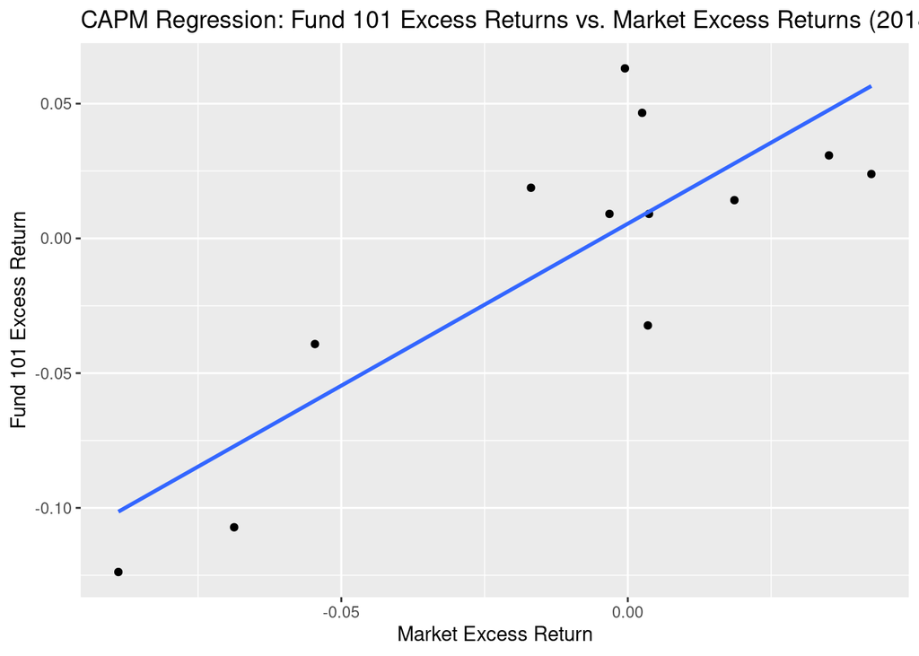

```r
capm_excess |>
  ggplot(aes(x = ReturnMarketExcess, y = ReturnFund101Excess)) +
  geom_point() +
  geom_smooth(method = "lm", se = FALSE) +
  labs(
    title = "CAPM Regression: Fund 101 Excess Returns vs. Market Excess Returns (2018)",
    x = "Market Excess Return",
    y = "Fund 101 Excess Return"
  )
```

**Analysis follow up:** You have plotted the curve fit are there any observations a unusual distance from the specified line? From what dates are these outlier observations?

Yes, there are a couple of observations that appear notably distant from the fitted CAPM regression line. After comparing the scatterplot against the fitted CAPM regression line, a few observations appear to deviate noticeably from what the model predicts. Specifically, the months May 2018, August 2018, and September 2018 show the largest residual values, indicating that the actual excess returns for Fund 101 were unusually far from the expected returns implied by its relationship with the market. In May and August 2018, the fund experienced much stronger positive excess returns than predicted based on market conditions, while in September 2018, the fund under-performed relative to what the model would have forecasted. These months represent atypical behavior for the fund and suggest that additional idiosyncratic factors beyond market movements influenced returns during these periods.

**NoteCAPM: Residual Plot**

**Exercise 5** From Exercise 3 model: plot the predicted model residuals (point).

**Residual Plot, Student**

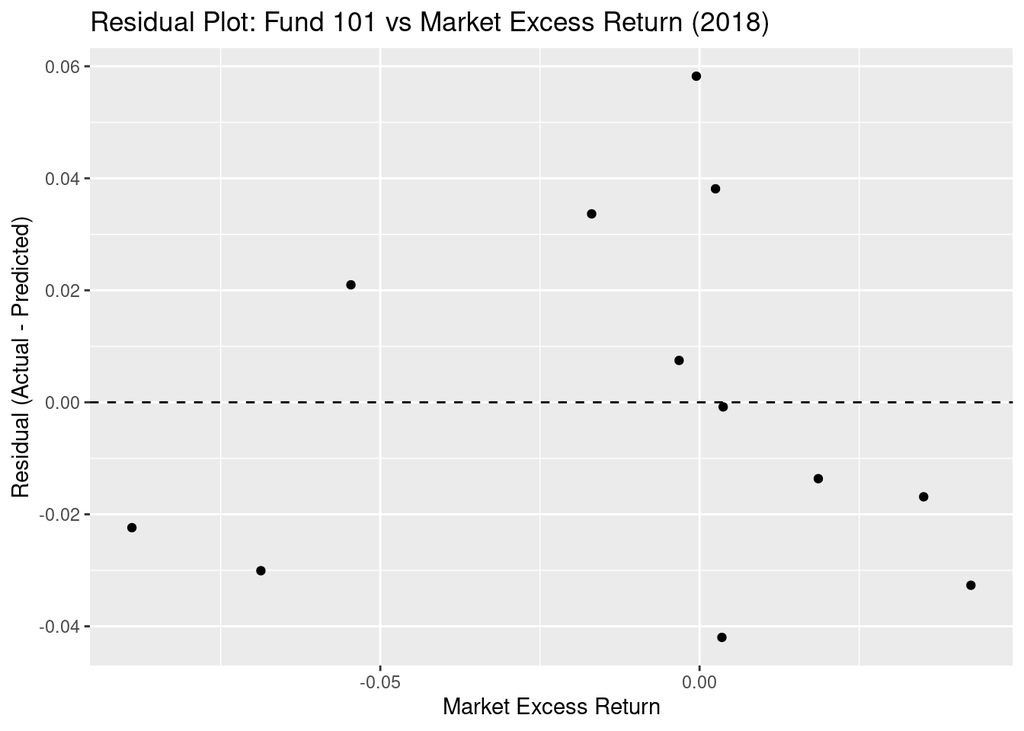

```r
#################################################################
# Student R code answer below
#################################################################
#################################################################
# Add residuals to the dataset
capm_residuals <- capm_excess |>
  mutate(residuals = resid(model_101))

# Plot residuals vs Market Excess Return
capm_residuals |>
  ggplot(aes(x = ReturnMarketExcess, y = residuals)) +
  geom_point() +
  geom_hline(yintercept = 0, linetype = "dashed") +
  labs(
    title = "Residual Plot: Fund 101 vs Market Excess Return (2018)",
    x = "Market Excess Return",
    y = "Residual (Actual - Predicted)"
  )
```

**Analysis follow up:** You have plotted the residuals does the visual appear that we have missed some function, possibly a sine wave or parabola ?

The residual plot does not show a strong pattern such as a curved, sine-wave, or U-shaped structure that would indicate a missing nonlinear component in the model. The points appear mostly scattered randomly around the zero line, which suggests that a simple linear model does a reasonable job capturing the relationship between Fund 101’s excess returns and the market’s excess returns. While there are a few larger positive and negative residual points, particularly during more volatile market months, these look like isolated outliers rather than evidence of a systematic non-linear pattern. Therefore, the CAPM single-factor linear regression appears appropriate for this fund over the 2018 period.

## Fama-French Three Factor Model (FF-3)

$$(R_{i} - R_{rf}) = β_{i} \cdot F_{market} + s_{i} \cdot F_{SMB} + h_{i} \cdot F_{HML} + \alpha_{i} + \epsilon_{i} \tag{2}$$

Table 4: Fama-French 3 Factor Asset Pricing Model (FF-3) Nomenclature

| Nomenclature | Definition |
| --- | --- |
| $R_{rf}$ | Risk free Rate |
| $R_m$ | Market Return |
| $F_{market}$ | Measure of the market factor FundId = 1 |
| $R_{i}$ | Fund’s Return |
| $ R_{i} - R_{rf}$ | Fund’s Excess Return |
| $\beta_{i}$ | Measure of the fund’s systematic risk compared to the market |
| $s_{i}$ | Measure of the fund’s exposure to the size factor |
| $F_{SMB}$ | Measure of the size factor FundId = 2 |
| $h_{i}$ | Measure of the fund’s exposure to the value factor |
| $F_{HML}$ | Measure of the market value factor FundId = 3 |
| $\alpha_{i}$ | Difference between the fund’s return and the expected return |

**NoteFama-French Three Factor Model: Arrange Data**

**Exercise 6** Now you may extend the model from a single factor to a multi-factor model. You will need to have the necessary Fama French Factor times series for the linear regression.

For this problem continue with FundId: 101 (iShares Core S&P Small Cap ETF). This exercises goal is to store the entire history and output the 2018 observations of the fields: `MonthEnd`, `ReturnFund101Excess`, `FamaFrenchMarket`, `FamaFrenchSize`, `FamaFrenchValue` .

**FF-3 Arrange, Student**

```r
#################################################################
# Student R code answer below
################################################################

# Select IDs needed for FF-3: Market (1), Size (2), Value (3), Risk-Free (7), Fund 101
ff3_ids <- c(1, 2, 3, 7, 101)

ff3_data <- returnsStack |>
  filter(FundId %in% ff3_ids) |>
  select(MonthEnd, FundId, ReturnMonthly) |>
  pivot_wider(
    names_from = FundId,
    values_from = ReturnMonthly,
    names_prefix = "Fund"
  )

# Prepare excess fund return and rename factor columns
ff3_excess <- ff3_data |>
  mutate(
    ReturnFund101Excess = Fund101 - Fund7,
    FamaFrenchMarket    = Fund1,
    FamaFrenchSize      = Fund2,
    FamaFrenchValue     = Fund3
  ) |>
  filter(lubridate::year(MonthEnd) == 2018) |>
  select(MonthEnd, ReturnFund101Excess, FamaFrenchMarket, FamaFrenchSize, FamaFrenchValue)

# Display results
ff3_excess |> gt()
```

| MonthEnd | ReturnFund101Excess | FamaFrenchMarket | FamaFrenchSize | FamaFrenchValue |
| --- | --- | --- | --- | --- |
| 2018-01-31 | 0.0239 | 0.0557 | -0.0312 | -0.0128 |
| 2018-02-28 | -0.0392 | -0.0365 | 0.0026 | -0.0104 |
| 2018-03-31 | 0.0188 | -0.0235 | 0.0406 | -0.0020 |
| 2018-04-30 | 0.0091 | 0.0029 | 0.0113 | 0.0054 |
| 2018-05-31 | 0.0631 | 0.0265 | 0.0526 | -0.0322 |
| 2018-06-30 | 0.0091 | 0.0048 | 0.0114 | -0.0233 |
| 2018-07-31 | 0.0308 | 0.0319 | -0.0222 | 0.0045 |
| 2018-08-31 | 0.0466 | 0.0344 | 0.0115 | -0.0400 |
| 2018-09-30 | -0.0323 | 0.0006 | -0.0229 | -0.0171 |
| 2018-10-31 | -0.1072 | -0.0768 | -0.0474 | 0.0340 |
| 2018-11-30 | 0.0142 | 0.0169 | -0.0068 | 0.0028 |
| 2018-12-31 | -0.1238 | -0.0957 | -0.0237 | -0.0188 |

**Analysis follow up:** Now that you have these columns calculated, describe in words how to estimate the sensitivity to size and value.

Sensitivity to Size and Value Factors To estimate a fund’s sensitivity to the size and value factors in the Fama-French Three-Factor Model, we run a multiple linear regression where the fund’s excess return is the dependent variable and the three Fama-French factors market excess return, SMB (size factor), and HML (value factor) are the independent variables. The coefficient on the SMB factor (often denoted si) measures the fund’s exposure to size, indicating whether the fund behaves more like small-cap stocks (positive value) or large-cap stocks (negative value). Similarly, the coefficient on the HML factor (denoted hi) measures exposure to value, showing whether the fund tilts toward high book-to-market “value” stocks (positive) or low book-to-market “growth” stocks (negative). These coefficient estimates quantify how much the fund’s performance is driven by systematic risks related to its weighting in small vs. large companies and value vs. growth characteristics.

**NoteFF-3: Estimate fund’s exposures to the three factor model.**

**Exercise 7** Using the data arranged in Exercise 6, estimate Fund 101’s Fama-French Three Factor Model, using Equation 2. Display the coefficients.

**FF3 Coefficients, Student**

```r
#################################################################
# Student R code answer below
#################################################################
# Run the Fama-French 3 Factor Regression
ff3_model_101 <- lm(
  ReturnFund101Excess ~
    FamaFrenchMarket +
    FamaFrenchSize +
    FamaFrenchValue,
  data = ff3_excess
)

# Display the coefficients (beta, s, h, alpha)
coef(ff3_model_101)
```

```
     (Intercept) FamaFrenchMarket   FamaFrenchSize  FamaFrenchValue
      0.00279652       1.05236363       0.89416265       0.33612852
```

**Analysis follow up:** So if $s_i$, the coefficient on the F_{SMB} (Small Capitalization minus Big Capitalization), is larger it this likely due to a large capitalization bias?

Although the SMB factor represents “Small Minus Big,” a larger positive value for si does not indicate a large-capitalization bias. Instead, it means the opposite. A positive and relatively large coefficient on the SMB factor shows that the fund performs more similarly to small-cap stocks, while a negative coefficient would indicate exposure to large-cap stocks. In this case, Fund 101’s estimated si value is approximately 0.89, which is strongly positive. This result suggests that the fund has a significant small-cap tilt, fully consistent with its objective as a small-capitalization equity ETF. Therefore, a large si does not imply large-cap bias — it reflects strong sensitivity to small-cap returns.

**NoteSelect fund with a small cap bias.**

**Exercise 8** You as tasked with comparing the following funds

Table 5: Fund for Analysis (Exercise 8)

| FundId | Fund Name |
| --- | --- |
| 101 | iShares Core S&P Small Cap ETF |
| 108 | iShares Morningstar Small-Cap ETF |
| 322 | Vanguard Small-Cap ETF |

For each model determine the FF3 Factor coefficients and display.

**Fund Small, Student**

```r
#################################################################
# Student R code answer below
#################################################################
# Funds for comparison
fund_ids <- c(101, 108, 322)
ff3_ids  <- c(1, 2, 3, 7)  # Market, SMB, HML, Risk-Free

# Extract needed data (Funds + FF3 factors + RF)
ff3_compare <- returnsStack |>
  filter(FundId %in% c(fund_ids, ff3_ids)) |>
  select(MonthEnd, FundId, ReturnMonthly) |>
  pivot_wider(
    names_from = FundId,
    values_from = ReturnMonthly,
    names_prefix = "Fund"
  ) |>
  mutate(
    # Excess returns for each small-cap fund
    Excess101 = Fund101 - Fund7,
    Excess108 = Fund108 - Fund7,
    Excess322 = Fund322 - Fund7,
    # Fama-French factor names
    FF_Market = Fund1,
    FF_Size   = Fund2,
    FF_Value  = Fund3
  ) |>
  filter(lubridate::year(MonthEnd) == 2018)

# Function to run FF-3 regression and return coefficients
run_ff3 <- function(y) {
  model <- lm(y ~ FF_Market + FF_Size + FF_Value,
              data = ff3_compare)
  coef(model)
}

# Run model for each fund and combine results
ff3_results <- tibble(
  Fund = c("Fund 101", "Fund 108", "Fund 322"),
  Coefficients = list(
    run_ff3(ff3_compare$Excess101),
    run_ff3(ff3_compare$Excess108),
    run_ff3(ff3_compare$Excess322)
  )
) |>
  unnest_wider(Coefficients)

ff3_results |> gt()
```

| Fund | (Intercept) | FF_Market | FF_Size | FF_Value |
| --- | --- | --- | --- | --- |
| Fund 101 | 0.002796520 | 1.0523636 | 0.8941626 | 0.3361285 |
| Fund 108 | -0.001807362 | 0.9361518 | 0.7062525 | 0.5411703 |
| Fund 322 | -0.001050884 | 0.9772911 | 0.6639539 | 0.1260872 |

**Analysis follow up:** A investor desires more exposure to the small capitalization market; which fund should be selected and why?

An investor seeking the greatest exposure to small-capitalization stocks should select Fund 101 (iShares Core S&P Small Cap ETF). This fund has the highest positive coefficient on the SMB factor (approximately 0.89), indicating that its performance is most strongly driven by returns associated with small-cap companies. In comparison, Funds 108 and 322 also exhibit positive small-cap exposure, but at lower levels (approximately 0.71 and 0.66, respectively). Therefore, Fund 101 provides the strongest alignment with a small-cap investment objective.

**NoteMacroeconomic Factors**

**Exercise 9** The Fama-French three-factor model uses fundamental factors relating to companies in the overall equity market. Other multi-factor models use macroeconomic factors. Can you think of some possible macroeconomic factors that would be good candidates for a multi-factor analysis?

Several broad economic variables can influence financial market performance and would serve as strong candidates for a multi-factor asset pricing model. Examples include interest rates (such as changes in the federal funds rate or Treasury yields), which impact borrowing costs and economic growth. Inflation measures like CPI or PPI are also important, as rising prices can reduce purchasing power and affect corporate profitability. GDP growth and broader measures of economic activity help capture expansion versus recession conditions. Factors related to the labor market, such as unemployment rates or wage growth, may reflect consumer spending strength. Additionally, commodity prices particularly oil influence costs for many sectors and can signal global demand levels. Exchange rates may also be relevant, especially for companies with international exposure. Using these macroeconomic factors could provide valuable insight into how economic conditions drive variations in asset returns beyond firm-level characteristics.

## Session Info

**CautionSession Info**

```r
date()
```

```
[1] "Thu Dec  4 14:01:18 2025"
```

```r
Sys.getenv()
```

[output not shown]

[output cut: 81 more lines]

[output not shown]